# Titanic Dataset

Karan Singh Aulakh

22 January 2017

R is an open-source programming language, meaning that users can contribute packages that make our lives easier, and we can use them for free. For this lab, and many others in the future, we will use the following R packages:

```r
library(dplyr)
```

```r
library(ggplot2)
library(scatterplot3d)
library(rgl)
library(lattice)
library(party)
```

You should have already installed these packages using commands like `install.packages`

To load the dataset Titanic, the csv file installed on the local machine is read using read.csv()

```r
Titanic <- read.csv("F:/Downloads/Titanic.csv")
```

Now, we need to determine the dimensions of the dataset Titanic.It can be determined by dim()

```r
dim(Titanic)
```

```
## [1] 1313    7
```

It can be seen that Titanic is a dataset consisting of 1313 rows and 7 columns.

Further investigating the properties of the dataset, we can examine the names of the variables and the structure of the dataset.

```r
names(Titanic)
```

```
## [1] "X"        "Name"     "PClass"   "Age"      "Sex"      "Survived"
## [7] "SexCode"
```

```r
str(Titanic)
```

```
## 'data.frame':    1313 obs. of  7 variables:
##  $ X       : int  1 2 3 4 5 6 7 8 9 10 ...
##  $ Name    : Factor w/ 1310 levels "Abbing, Mr Anthony",..: 22 25 26 27 24 31 45 46 50 54 ...
##  $ PClass  : Factor w/ 4 levels "*","1st","2nd",..: 2 2 2 2 2 2 2 2 2 2 ...
##  $ Age     : num  29 2 30 25 0.92 47 63 39 58 71 ...
##  $ Sex     : Factor w/ 2 levels "female","male": 1 1 2 1 2 2 1 2 1 2 ...
##  $ Survived: int  1 0 0 0 1 1 1 0 1 0 ...
##  $ SexCode : int  1 1 0 1 0 0 1 0 1 0 ...
```

Let us have a look at the first 10 rows of the dataset.

```r
head(Titanic[1:7],10)
```

```
##     X                                          Name PClass   Age    Sex
## 1   1                  Allen, Miss Elisabeth Walton    1st 29.00 female
## 2   2                   Allison, Miss Helen Loraine    1st  2.00 female
## 3   3           Allison, Mr Hudson Joshua Creighton    1st 30.00   male
## 4   4 Allison, Mrs Hudson JC (Bessie Waldo Daniels)    1st 25.00 female
## 5   5                 Allison, Master Hudson Trevor    1st  0.92   male
## 6   6                            Anderson, Mr Harry    1st 47.00   male
## 7   7              Andrews, Miss Kornelia Theodosia    1st 63.00 female
## 8   8                        Andrews, Mr Thomas, jr    1st 39.00   male
## 9   9  Appleton, Mrs Edward Dale (Charlotte Lamson)    1st 58.00 female
## 10 10                        Artagaveytia, Mr Ramon    1st 71.00   male
##    Survived SexCode
## 1         1       1
## 2         0       1
## 3         0       0
## 4         0       1
## 5         1       0
## 6         1       0
## 7         1       1
## 8         0       0
## 9         1       1
## 10        0       0
```

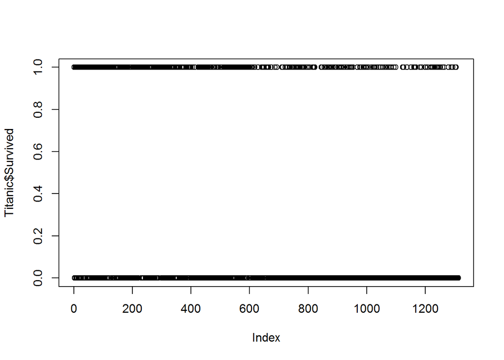

```r
plot(Titanic$Survived)
```

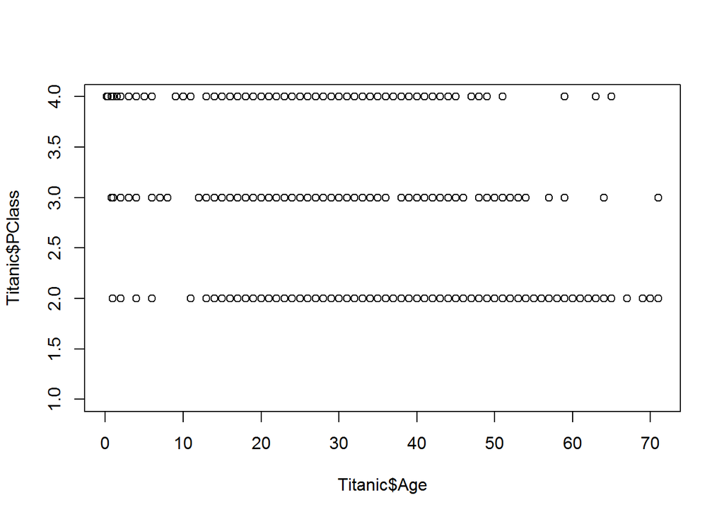

```r
plot(Titanic$Age,Titanic$PClass)
```